# Loading and preprocessing the data

## Loading and preprocessing the data

Loading data:

```r
rawdata = read.csv("./activity.csv");
```

Processing data: Not necessary.

## What is mean total number of steps taken per day?

Calculate the total number of steps taken per day

```r
numStepsPerDate = aggregate(steps ~ date, data = rawdata, sum)
```

Make a histogram of the total number of steps taken each day

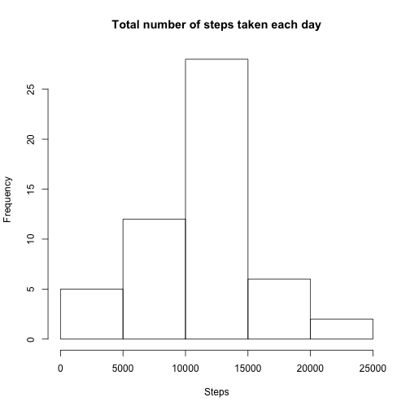

```r
hist(numStepsPerDate$steps,main = "Total number of steps taken each day",xlab="Steps")
```

Calculate and report the mean and median of the total number of steps taken per day

```r
 meanSteps = as.integer(mean(numStepsPerDate$steps))
```

```r
 medianSteps= as.integer(median(numStepsPerDate$steps))
```

- *The mean of the total number of steps taken per day is:* 10766.
- *The median of the total number of steps taken per day is:* 10765.

## What is the average daily activity pattern?

Make a time series plot (i.e. type = “l”) of the 5-minute interval (x-axis) and the average number of steps taken, averaged across all days (y-axis)

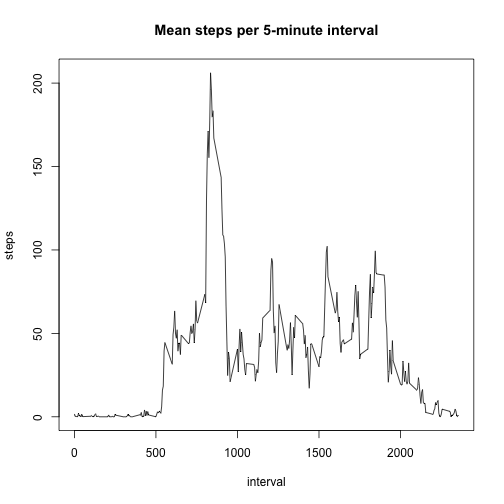

```r
meanStepsPerInterval = aggregate(steps ~ interval, data = rawdata, mean)
plot(steps ~ interval, data = meanStepsPerInterval, type = "l")
title(main = "Mean steps per 5-minute interval")
```

Which 5-minute interval, on average across all the days in the dataset, contains the maximum number of steps?

```r
filtered = meanStepsPerInterval[which.max(meanStepsPerInterval$steps), ];
filtered$interval
```

```
## [1] 835
```

*The 5-minute interval that contains the maximum number of step, on average across all the days in the dataset is: * 835.

## Imputing missing values

Calculate and report the total number of missing values in the dataset

```r
missingvalues = sum(is.na(rawdata))
```

*The total number of missing values in the dataset is:* 2304.

Devise a strategy for filling in all of the missing values in the dataset.

*Strategy: Replace missing values in the column “steps” with its mean on that interval*

Create a new dataset that is equal to the original dataset but with the missing data filled in.

```r
#Function to get the mean steps for the interval from the aggregated data in variable
#"meanStepsPerInterval"

getMeanStepsOfInterval = function(interval) {

  meanStepsPerInterval[meanStepsPerInterval$interval == interval, ]$steps
}

#For all rows in the original dataset with NA in the column "steps", replace the NA by the mean steps for the interval of the row

withoutNA = rawdata;
numNA = 0;
for (i in 1:nrow(withoutNA)) {
    if (is.na(withoutNA[i, ]$steps)) {
        numNA = numNA + 1;
        interval = withoutNA[i, ]$interval;

        #get the mean steps for the interval from the aggregated data in variable
        #"meanStepsPerInterval"
        withoutNA[i, ]$steps =  getMeanStepsOfInterval(interval)
    }
}
```

2304 *missing values replaced*.

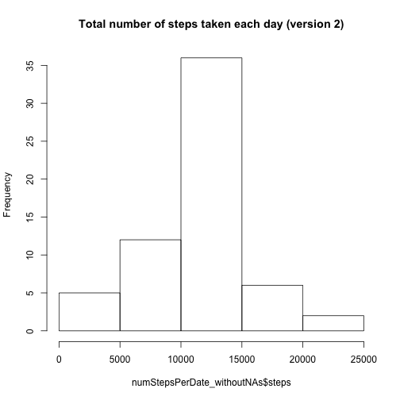

```r
numStepsPerDate_withoutNAs = aggregate(steps ~ date, data = withoutNA, sum)
hist(numStepsPerDate_withoutNAs$steps,main = "Total number of steps taken each day (version 2)")
```

## Are there differences in activity patterns between weekdays and weekends?

*The following code will install package “lubridate” if not found

```r
rawdates = as.Date(withoutNA$date);
if (!require(lubridate)){
  install.packages("lubridate")
  library(lubridate)
}
withoutNA$dateAsDay = factor(ifelse(wday(rawdates)%%6 == 0, "weekend", "weekday"))
```

Make a panel plot containing a time series plot (i.e. type = “l”) of the 5-minute interval (x-axis) and the average number of steps taken, averaged across all weekday days or weekend days (y-axis). See the README file in the GitHub repository to see an example of what this plot should look like using simulated data.

*The following code will install package “lattice” if not found

```r
meanStepsPerInterval2 = aggregate(steps ~ interval + dateAsDay, data = withoutNA, mean)
if (!require(lattice)){
  install.packages("lattice")
  library(lattice)
}
```

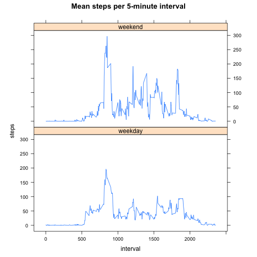

```r
xyplot(steps ~ interval | dateAsDay, data = meanStepsPerInterval2, aspect = 1/2, type = "l",main = "Mean steps per 5-minute interval")
```